# AIML_ML_Project_full_code_notebook

## Problem Statement

### Context

AllLife Bank is a US bank that has a growing customer base. The majority of these customers are liability customers (depositors) with varying sizes of deposits. The number of customers who are also borrowers (asset customers) is quite small, and the bank is interested in expanding this base rapidly to bring in more loan business and in the process, earn more through the interest on loans. In particular, the management wants to explore ways of converting its liability customers to personal loan customers (while retaining them as depositors).

A campaign that the bank ran last year for liability customers showed a healthy conversion rate of over 9% success. This has encouraged the retail marketing department to devise campaigns with better target marketing to increase the success ratio.

You as a Data scientist at AllLife bank have to build a model that will help the marketing department to identify the potential customers who have a higher probability of purchasing the loan.

### Objective

To predict whether a liability customer will buy personal loans, to understand which customer attributes are most significant in driving purchases, and identify which segment of customers to target more.

### Data Dictionary

- `ID`: Customer ID
- `Age`: Customer’s age in completed years
- `Experience`: #years of professional experience
- `Income`: Annual income of the customer (in thousand dollars)
- `ZIP Code`: Home Address ZIP code.
- `Family`: the Family size of the customer
- `CCAvg`: Average spending on credit cards per month (in thousand dollars)
- `Education`: Education Level. 1: Undergrad; 2: Graduate;3: Advanced/Professional
- `Mortgage`: Value of house mortgage if any. (in thousand dollars)
- `Personal_Loan`: Did this customer accept the personal loan offered in the last campaign? (0: No, 1: Yes)
- `Securities_Account`: Does the customer have securities account with the bank? (0: No, 1: Yes)
- `CD_Account`: Does the customer have a certificate of deposit (CD) account with the bank? (0: No, 1: Yes)
- `Online`: Do customers use internet banking facilities? (0: No, 1: Yes)
- `CreditCard`: Does the customer use a credit card issued by any other Bank (excluding All life Bank)? (0: No, 1: Yes)

## Importing necessary libraries

```python
# Installing the libraries with the specified version.
# !pip install numpy==1.25.2 pandas==1.5.3 matplotlib==3.7.1 seaborn==0.13.1 scikit-learn==1.2.2 sklearn-pandas==2.2.0 -q --user
```

**Note**:

1. After running the above cell, kindly restart the notebook kernel (for Jupyter Notebook) or runtime (for Google Colab), write the relevant code for the project from the next cell, and run all cells sequentially from the next cell.
2. On executing the above line of code, you might see a warning regarding package dependencies. This error message can be ignored as the above code ensures that all necessary libraries and their dependencies are maintained to successfully execute the code in this notebook.

```python
# Libraries to help with reading and manipulating data
import pandas as pd
import numpy as np

# libaries to help with data visualization
import matplotlib.pyplot as plt
import seaborn as sns

# Library to split data
from sklearn.model_selection import train_test_split

# To build model for prediction
from sklearn.tree import DecisionTreeClassifier
from sklearn import tree

# To get different metric scores
from sklearn.metrics import (
    f1_score,
    accuracy_score,
    recall_score,
    precision_score,
    confusion_matrix,
)

# To ignore unnecessary warnings
import warnings
warnings.filterwarnings("ignore")
```

## Loading the dataset

```python
from google.colab import drive
drive.mount('/content/drive')
```

```python
# Load loan modelling data from the csv file
loan_modelling_data = pd.read_csv("/content/drive/MyDrive/Colab Notebooks/PGP-AIML/Partha/ML-Project/Loan_Modelling.csv")
```

```python
# Make a copy of the original data.
data = loan_modelling_data.copy()
```

## Data Overview

- Observations
- Sanity checks

### Check if loan data is loaded to dataframe

```python
# Check first 5 rows
data.head()
```

|  | ID | Age | Experience | Income | ZIPCode | Family | CCAvg | Education | Mortgage | Personal_Loan | Securities_Account | CD_Account | Online | CreditCard |
| --- | --- | --- | --- | --- | --- | --- | --- | --- | --- | --- | --- | --- | --- | --- |
| 0 | 1 | 25 | 1 | 49 | 91107 | 4 | 1.6 | 1 | 0 | 0 | 1 | 0 | 0 | 0 |
| 1 | 2 | 45 | 19 | 34 | 90089 | 3 | 1.5 | 1 | 0 | 0 | 1 | 0 | 0 | 0 |
| 2 | 3 | 39 | 15 | 11 | 94720 | 1 | 1.0 | 1 | 0 | 0 | 0 | 0 | 0 | 0 |
| 3 | 4 | 35 | 9 | 100 | 94112 | 1 | 2.7 | 2 | 0 | 0 | 0 | 0 | 0 | 0 |
| 4 | 5 | 35 | 8 | 45 | 91330 | 4 | 1.0 | 2 | 0 | 0 | 0 | 0 | 0 | 1 |

```python
# Check last 5 rows
data.tail()
```

|  | ID | Age | Experience | Income | ZIPCode | Family | CCAvg | Education | Mortgage | Personal_Loan | Securities_Account | CD_Account | Online | CreditCard |
| --- | --- | --- | --- | --- | --- | --- | --- | --- | --- | --- | --- | --- | --- | --- |
| 4995 | 4996 | 29 | 3 | 40 | 92697 | 1 | 1.9 | 3 | 0 | 0 | 0 | 0 | 1 | 0 |
| 4996 | 4997 | 30 | 4 | 15 | 92037 | 4 | 0.4 | 1 | 85 | 0 | 0 | 0 | 1 | 0 |
| 4997 | 4998 | 63 | 39 | 24 | 93023 | 2 | 0.3 | 3 | 0 | 0 | 0 | 0 | 0 | 0 |
| 4998 | 4999 | 65 | 40 | 49 | 90034 | 3 | 0.5 | 2 | 0 | 0 | 0 | 0 | 1 | 0 |
| 4999 | 5000 | 28 | 4 | 83 | 92612 | 3 | 0.8 | 1 | 0 | 0 | 0 | 0 | 1 | 1 |

#### **Observation**

- Data seems to have loaded fine.

### Checking the shape of the dataset

```python
# Check for the shape of the dataset
print(f"There are {data.shape[0]} rows and {data.shape[1]} columns.")
```

```
There are 5000 rows and 14 columns.
```

#### **Observation**

- There are 5000 rows and 14 columns.

### Checking for the structure of the dataset

```python
# Check datatypes
data.info()
```

```
<class 'pandas.core.frame.DataFrame'>
RangeIndex: 5000 entries, 0 to 4999
Data columns (total 14 columns):
 #   Column              Non-Null Count  Dtype
---  ------              --------------  -----
 0   ID                  5000 non-null   int64
 1   Age                 5000 non-null   int64
 2   Experience          5000 non-null   int64
 3   Income              5000 non-null   int64
 4   ZIPCode             5000 non-null   int64
 5   Family              5000 non-null   int64
 6   CCAvg               5000 non-null   float64
 7   Education           5000 non-null   int64
 8   Mortgage            5000 non-null   int64
 9   Personal_Loan       5000 non-null   int64
 10  Securities_Account  5000 non-null   int64
 11  CD_Account          5000 non-null   int64
 12  Online              5000 non-null   int64
 13  CreditCard          5000 non-null   int64
dtypes: float64(1), int64(13)
memory usage: 547.0 KB
```

#### **Observation**

- There are 13 integer columns and 1 float column. 14 coulmns in total.
- None of the columns have null value. There are no missing values

### Check for missing values (double check)

```python
# Check for missing values
data.isnull().sum()
```

|  | 0 |
| --- | --- |
| ID | 0 |
| Age | 0 |
| Experience | 0 |
| Income | 0 |
| ZIPCode | 0 |
| Family | 0 |
| CCAvg | 0 |
| Education | 0 |
| Mortgage | 0 |
| Personal_Loan | 0 |
| Securities_Account | 0 |
| CD_Account | 0 |
| Online | 0 |
| CreditCard | 0 |

**dtype:** int64

#### **Observation**

- As we saw which info(), there are no missing values.

### Check for duplicate Records

```python
# Check for dupliate records in dataset
dup_count = data.duplicated().sum()
print(f"There are {dup_count} duplicate records in the dataset.")
```

```
There are 0 duplicate records in the dataset.
```

#### **Observation**

- There are 0 duplicate records in the dataset.

### Statistical Summary

```python
# Statistical summary
data.describe().T
```

|  | count | mean | std | min | 25% | 50% | 75% | max |
| --- | --- | --- | --- | --- | --- | --- | --- | --- |
| ID | 5000.0 | 2500.500000 | 1443.520003 | 1.0 | 1250.75 | 2500.5 | 3750.25 | 5000.0 |
| Age | 5000.0 | 45.338400 | 11.463166 | 23.0 | 35.00 | 45.0 | 55.00 | 67.0 |
| Experience | 5000.0 | 20.104600 | 11.467954 | -3.0 | 10.00 | 20.0 | 30.00 | 43.0 |
| Income | 5000.0 | 73.774200 | 46.033729 | 8.0 | 39.00 | 64.0 | 98.00 | 224.0 |
| ZIPCode | 5000.0 | 93169.257000 | 1759.455086 | 90005.0 | 91911.00 | 93437.0 | 94608.00 | 96651.0 |
| Family | 5000.0 | 2.396400 | 1.147663 | 1.0 | 1.00 | 2.0 | 3.00 | 4.0 |
| CCAvg | 5000.0 | 1.937938 | 1.747659 | 0.0 | 0.70 | 1.5 | 2.50 | 10.0 |
| Education | 5000.0 | 1.881000 | 0.839869 | 1.0 | 1.00 | 2.0 | 3.00 | 3.0 |
| Mortgage | 5000.0 | 56.498800 | 101.713802 | 0.0 | 0.00 | 0.0 | 101.00 | 635.0 |
| Personal_Loan | 5000.0 | 0.096000 | 0.294621 | 0.0 | 0.00 | 0.0 | 0.00 | 1.0 |
| Securities_Account | 5000.0 | 0.104400 | 0.305809 | 0.0 | 0.00 | 0.0 | 0.00 | 1.0 |
| CD_Account | 5000.0 | 0.060400 | 0.238250 | 0.0 | 0.00 | 0.0 | 0.00 | 1.0 |
| Online | 5000.0 | 0.596800 | 0.490589 | 0.0 | 0.00 | 1.0 | 1.00 | 1.0 |
| CreditCard | 5000.0 | 0.294000 | 0.455637 | 0.0 | 0.00 | 0.0 | 1.00 | 1.0 |

### Drop ID column

```python
# Drop ID column
# Since ID is a unique Identifier, lets drop that column
data.drop(columns=["ID"], inplace=True)
```

```python
# Check dataset after dropping ID column
data.head()
```

|  | Age | Experience | Income | ZIPCode | Family | CCAvg | Education | Mortgage | Personal_Loan | Securities_Account | CD_Account | Online | CreditCard |
| --- | --- | --- | --- | --- | --- | --- | --- | --- | --- | --- | --- | --- | --- |
| 0 | 25 | 1 | 49 | 91107 | 4 | 1.6 | 1 | 0 | 0 | 1 | 0 | 0 | 0 |
| 1 | 45 | 19 | 34 | 90089 | 3 | 1.5 | 1 | 0 | 0 | 1 | 0 | 0 | 0 |
| 2 | 39 | 15 | 11 | 94720 | 1 | 1.0 | 1 | 0 | 0 | 0 | 0 | 0 | 0 |
| 3 | 35 | 9 | 100 | 94112 | 1 | 2.7 | 2 | 0 | 0 | 0 | 0 | 0 | 0 |
| 4 | 35 | 8 | 45 | 91330 | 4 | 1.0 | 2 | 0 | 0 | 0 | 0 | 0 | 1 |

### Deal negative value in experience column

```python
# Check for number of unique experience data
data.Experience.unique()
```

```
array([ 1, 19, 15,  9,  8, 13, 27, 24, 10, 39,  5, 23, 32, 41, 30, 14, 18,
       21, 28, 31, 11, 16, 20, 35,  6, 25,  7, 12, 26, 37, 17,  2, 36, 29,
        3, 22, -1, 34,  0, 38, 40, 33,  4, -2, 42, -3, 43])
```

```python
# Check for unique negative experience
data[data.Experience < 0].Experience.value_counts()
```

| Experience | count |
| --- | --- |
| -1 | 33 |
| -2 | 15 |
| -3 | 4 |

**dtype:** int64

```python
# Check number of records with negative experience
print(f"There are {data[data.Experience < 0].shape[0]} records with negative experience.")
```

```
There are 52 records with negative experience.
```

```python
# Lets convert negative experience to possitive experience assuming data entry error
data.loc[data.Experience < 0, "Experience"] = data.loc[data.Experience < 0, "Experience"] * -1
```

```python
# Check number of records with negative experience after the above fix
print(f"There are {data[data.Experience < 0].shape[0]} records with negative experience.")
```

```
There are 0 records with negative experience.
```

## Exploratory Data Analysis.

- EDA is an important part of any project involving data.
- It is important to investigate and understand the data better before building a model with it.
- A few questions have been mentioned below which will help you approach the analysis in the right manner and generate insights from the data.
- A thorough analysis of the data, in addition to the questions mentioned below, should be done.

**Define functions that are needed to carry out the EDA.**

```python
# Function to create histogram and boxplots

def histogram_boxplot(data, feature, figsize=(15, 10), kde=False, bins=None):
    """
    Boxplot and histogram combined

    data: dataframe
    feature: dataframe column
    figsize: size of figure (default (15,10))
    kde: whether to show the density curve (default False)
    bins: number of bins for histogram (default None)
    """

    plt.figure(figsize=figsize)
    f2, (ax_box2, ax_hist2) = plt.subplots(
        nrows=2,  # Number of rows of the subplot grid= 2
        sharex=True,  # x-axis will be shared among all subplots
        gridspec_kw={"height_ratios": (0.25, 0.75)},
        figsize=figsize,
    )  # creating the 2 subplots
    sns.boxplot(
        data=data, x=feature, ax=ax_box2, showmeans=True, color="violet"
    )  # boxplot will be created and a triangle will indicate the mean value of the column
    sns.histplot(
        data=data, x=feature, kde=kde, ax=ax_hist2, bins=bins
    ) if bins else sns.histplot(
        data=data, x=feature, kde=kde, ax=ax_hist2
    )  # For histogram
    ax_hist2.axvline(
        data[feature].mean(), color="green", linestyle="--"
    )  # Add mean to the histogram
    ax_hist2.axvline(
        data[feature].median(), color="black", linestyle="-"
    )  # Add median to the histogram
```

```python
# function to create labeled barplots


def labeled_barplot(data, feature, perc=False, n=None):
    """
    Barplot with percentage at the top

    data: dataframe
    feature: dataframe column
    perc: whether to display percentages instead of count (default is False)
    n: displays the top n category levels (default is None, i.e., display all levels)
    """

    total = len(data[feature])  # length of the column
    count = data[feature].nunique()
    if n is None:
        plt.figure(figsize=(count + 2, 6))
    else:
        plt.figure(figsize=(n + 2, 6))

    plt.xticks(rotation=90, fontsize=15)
    ax = sns.countplot(
        data=data,
        x=feature,
        palette="Paired",
        order=data[feature].value_counts().index[:n],
    )

    for p in ax.patches:
        if perc == True:
            label = "{:.1f}%".format(
                100 * p.get_height() / total
            )  # percentage of each class of the category
        else:
            label = p.get_height()  # count of each level of the category

        x = p.get_x() + p.get_width() / 2  # width of the plot
        y = p.get_height()  # height of the plot

        ax.annotate(
            label,
            (x, y),
            ha="center",
            va="center",
            size=12,
            xytext=(0, 5),
            textcoords="offset points",
        )  # annotate the percentage

    plt.show()  # show the plot
```

```python
# Function to create stacked barplot
def stacked_barplot(data, predictor, target):
    """
    Print the category counts and plot a stacked bar chart

    data: dataframe
    predictor: independent variable
    target: target variable
    """
    count = data[predictor].nunique()
    sorter = data[target].value_counts().index[-1]
    tab1 = pd.crosstab(data[predictor], data[target], margins=True).sort_values(
        by=sorter, ascending=False
    )
    print(tab1)
    print("-" * 120)
    tab = pd.crosstab(data[predictor], data[target], normalize="index").sort_values(
        by=sorter, ascending=False
    )
    tab.plot(kind="bar", stacked=True, figsize=(count + 5, 5))
    plt.legend(
        loc="lower left", frameon=False,
    )
    plt.legend(loc="upper left", bbox_to_anchor=(1, 1))
    plt.show()
```

```python
### function to plot distributions wrt target


def distribution_plot_wrt_target(data, predictor, target):

    fig, axs = plt.subplots(2, 2, figsize=(12, 10))

    target_uniq = data[target].unique()

    axs[0, 0].set_title("Distribution of target for target=" + str(target_uniq[0]))
    sns.histplot(
        data=data[data[target] == target_uniq[0]],
        x=predictor,
        kde=True,
        ax=axs[0, 0],
        color="teal",
        stat="density",
    )

    axs[0, 1].set_title("Distribution of target for target=" + str(target_uniq[1]))
    sns.histplot(
        data=data[data[target] == target_uniq[1]],
        x=predictor,
        kde=True,
        ax=axs[0, 1],
        color="orange",
        stat="density",
    )

    axs[1, 0].set_title("Boxplot w.r.t target")
    sns.boxplot(data=data, x=target, y=predictor, ax=axs[1, 0], palette="gist_rainbow")

    axs[1, 1].set_title("Boxplot (without outliers) w.r.t target")
    sns.boxplot(
        data=data,
        x=target,
        y=predictor,
        ax=axs[1, 1],
        showfliers=False,
        palette="gist_rainbow",
    )

    plt.tight_layout()
    plt.show()
```

### **Univariate Analysis**

#### **1. Age**

*Customer’s age in completed years*

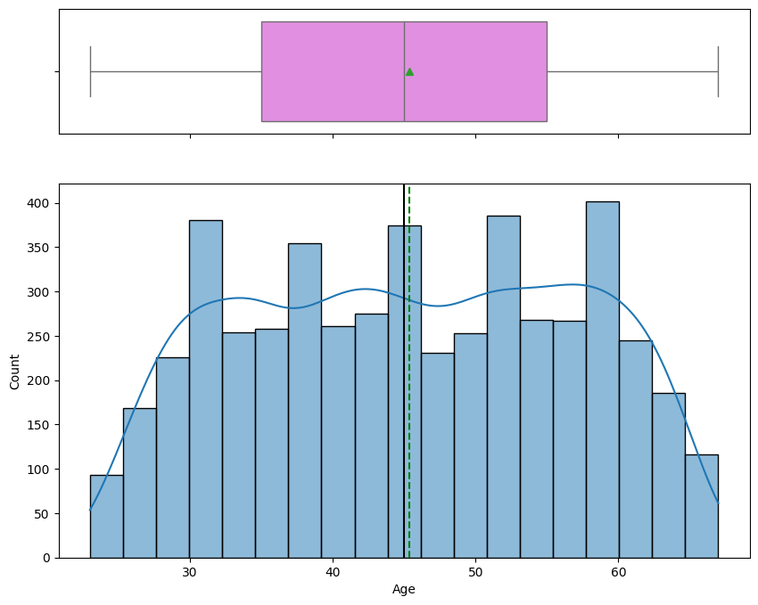

```python
# Histogram and Boxplot for Age
histogram_boxplot(data, "Age", (10, 8), kde=True)
```

#### **2. Experience**

*#years of professional experience*

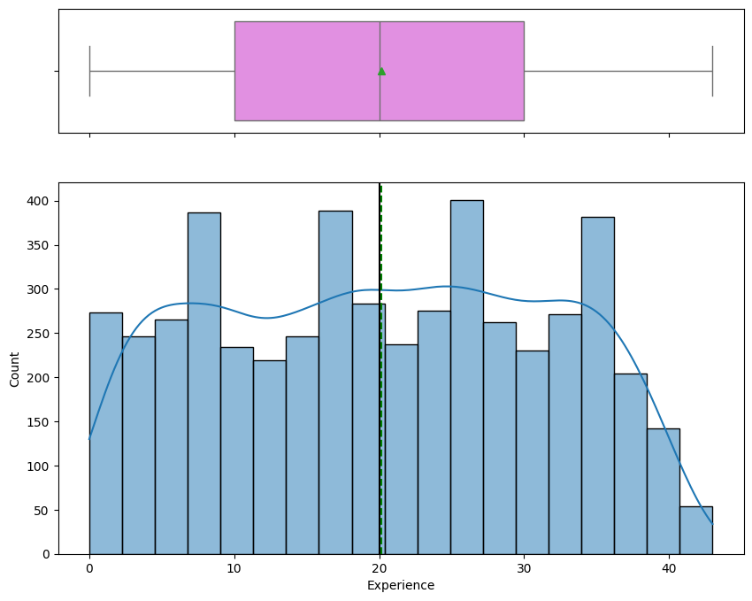

```python
# Histogram and box plot for experience
histogram_boxplot(data, "Experience", (10, 8), kde=True)
```

#### **3. Income**

*Annual income of the customer (in thousand dollars)*

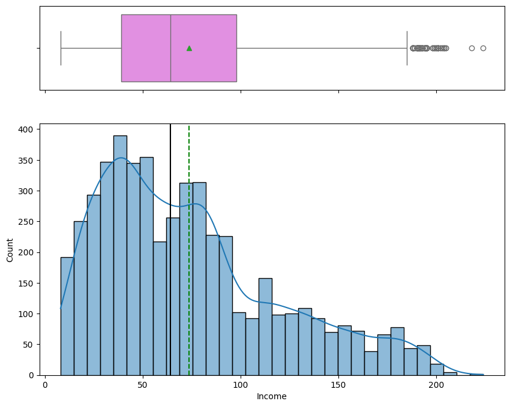

```python
# Histogram and Box plot for income
histogram_boxplot(data, "Income", (10, 8), kde=True)
```

##### **Observation**

- The distribution of Income is strongly right-skewed, it shows a long tail extending beyond 200K
- Most of data is distributed between 0-100K
- From the boxplot we can observe multiple outliers. Need to check and treat if if necessary.

#### **4. ZIP Code**

*Home Address ZIP code.*

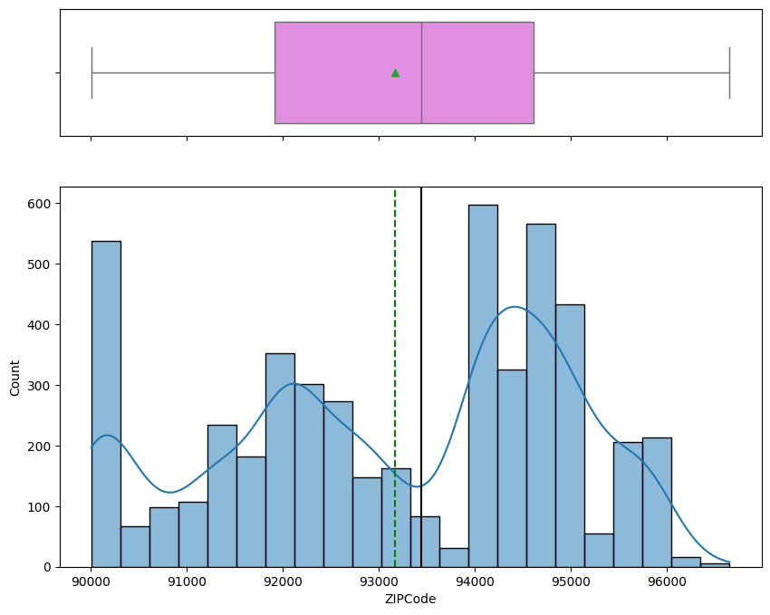

```python
# Histogram and boxplot for ZIP Code
histogram_boxplot(data, "ZIPCode", (10, 8), kde=True)
```

##### **Observation**

- The ZIP codes appears to be from California (90000-96999) (Zip code info obtained from internet)
- There are 3 peak 90000-90999, 92000-92999 and 94000-95999
- Rather using raw zip code, may be we should create a grouping. In any case ZipCode should be treated.

#### **5. Family**

*the Family size of the customer*

```
Family
1    1472
2    1296
4    1222
3    1010
Name: count, dtype: int64
```

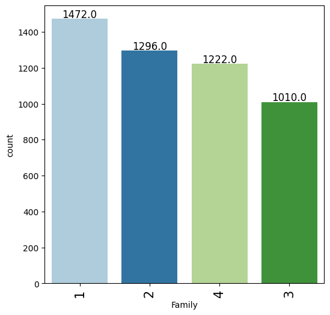

```python
print(data.Family.value_counts())
# Labeled barplot for Family
labeled_barplot(data, "Family")
```

##### **Observation**

- More customer have family size of 1. On the whole the distribution is relatively even across family size.

#### **6. CCAvg**

*Average spending on credit cards per month (in thousand dollars)*

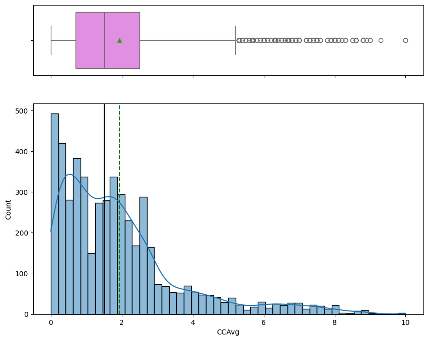

```python
# Histogram and bar plot for CCAvg
histogram_boxplot(data, "CCAvg", (10, 8), kde=True)
```

##### **Observation**

- The distribution is strongly right-skewed.
- There are many outliers.

#### **7. Education**

*Education Level. 1: Undergrad; 2: Graduate;3: Advanced/Professional*

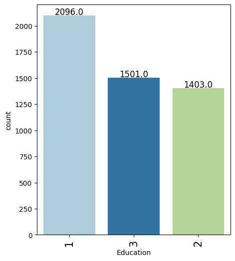

```python
# Labled barplot for Education Level
labeled_barplot(data, "Education")
```

##### **Observation**

- About 41.9% of are Undergrads (2096/5000)
- Graduate and Advance/Professional are more or less the same distribution.

#### **8. Mortgage**

*Value of house mortgage if any. (in thousand dollars)*

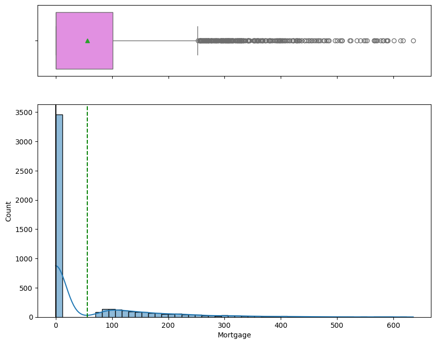

```python
# Histogram and Boxplot for Mortgage
histogram_boxplot(data, "Mortgage", (10, 8), kde=True)
```

##### **Observation**

- The distribution is extremely right-skewed
- 70% do not have mortgage.
- Among the people with mortgage the common range is 100-200K
- The are lot of outliers, it is visible from the boxplot.

#### **9. Personal_Loan**

*Did this customer accept the personal loan offered in the last campaign?*

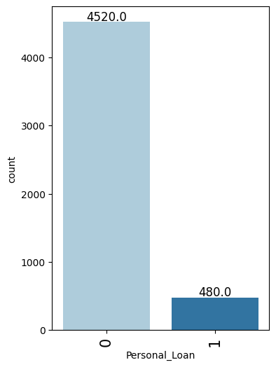

```python
# Labeled barplot for Personal_Loan
labeled_barplot(data, "Personal_Loan")
```

##### **Observation**

- Majority of the customer did not accept personal loan during last campaign.

#### **10. Securities_Account**

*Does the customer have securities account with the bank?*

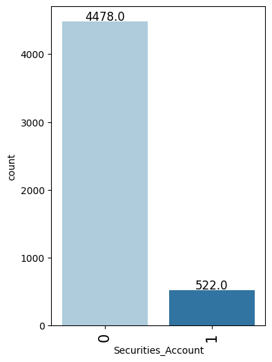

```python
# Labeled barplot for Securities_Account
labeled_barplot(data, "Securities_Account")
```

##### **Observation**

- About 10% of the customer only have securities.

#### **11. CD_Account**

*Does the customer have a certificate of deposit (CD) account with the bank?*

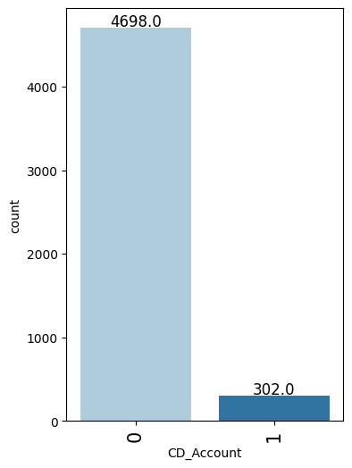

```python
# Labeled barplot for CD_Account
labeled_barplot(data, "CD_Account")
```

##### **Observation**

- Only 6% of the customer have CD account

#### **12. Online**

*Do customers use internet banking facilities?*

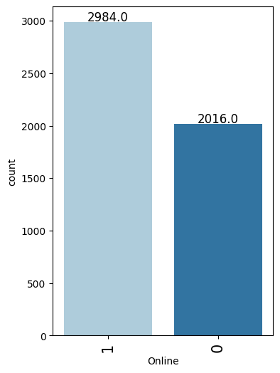

```python
# Labeled barplot for Online usage
labeled_barplot(data, "Online")
```

##### **Observation**

- There is an approximate 60-40% split of customer using online banking and those who don't.

#### **13. CreditCard**

*Does the customer use a credit card issued by any other Bank (excluding All life Bank)?*

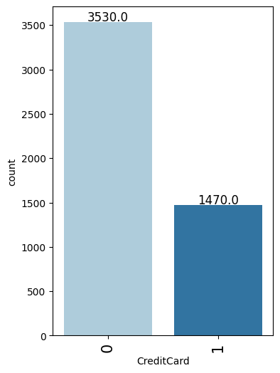

```python
# Labeled barplot for CreditCard
labeled_barplot(data, "CreditCard")
```

##### **Observation**

- 29.4% of customer use credit card used by other banks

### **Bivariate Analysis**

#### **Correlation of Data (Heat Map)**

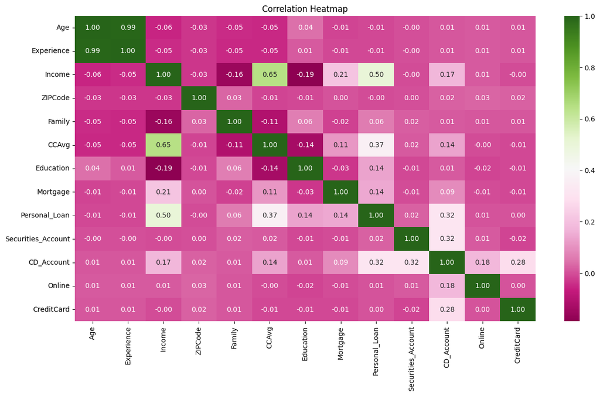

```python
# Correlation heatmap
plt.figure(figsize=(15, 8))
plt.title("Correlation Heatmap")
sns.heatmap(data.corr(), annot=True, cmap="PiYG", fmt='.2f')
plt.show()
```

##### **Observation**

- Age and Experience have almost perfect correlation (0.99). The capture similar information.
- Income and CCAvg has positive correlation (0.65), higher the income higher the credit card spending.
- Income and Personal_loan also has positive correlation (0.50), higher income is linked to accepting of personal loan.
- Credit card spending is moderately associated with personal loan acceptance (0.37)
- CD account holder are more likely to have personal loans, a correlation of 0.32.
- ZIP Code show minimal correlation with other variables.
- Education has week correlation with other variables as well.

#### *Let's check how a customer's interest in purchasing a loan varies with respect to other variables*

```
Personal_Loan     0    1   All
Family
All            4520  480  5000
4              1088  134  1222
3               877  133  1010
1              1365  107  1472
2              1190  106  1296
------------------------------------------------------------------------------------------------------------------------
```

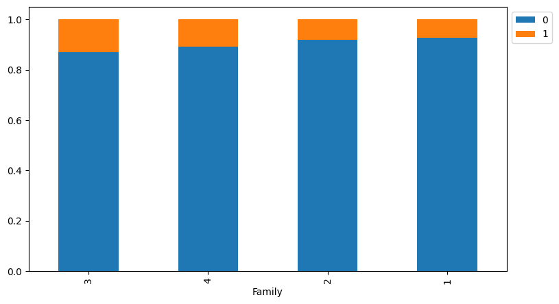

```python
# Lets do a stacked_barplot for columns with few unique values
cat_columns = ["Family", "Education", "CD_Account", "Online", "CreditCard","Securities_Account"]
# Let me analyse one column at a time.
# for col in cat_columns:
#     stacked_barplot(data, col, "Personal_Loan")

# Personal_Loan Vs Family
stacked_barplot(data, "Family", "Personal_Loan")
```

**Observation**

- Family of size 3 and 4 show slighty more interest in getting a loan.

```
Personal_Loan     0    1   All
Education
All            4520  480  5000
3              1296  205  1501
2              1221  182  1403
1              2003   93  2096
------------------------------------------------------------------------------------------------------------------------
```

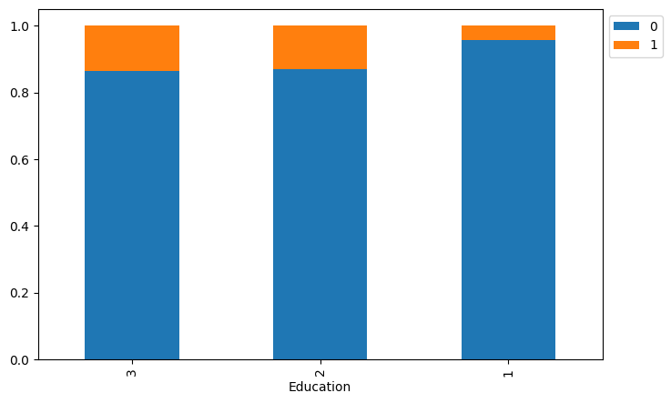

```python
# Personal_Loan Vs Education
stacked_barplot(data, "Education", "Personal_Loan")
```

**Observation**

- There is a clear impact of education level with respect to accepting personal loan
- Higher educated customer (Graduate and Advanced) shows more acceptance.
- Undergrads have much lower acceptance.

```
Personal_Loan     0    1   All
CD_Account
All            4520  480  5000
0              4358  340  4698
1               162  140   302
------------------------------------------------------------------------------------------------------------------------
```

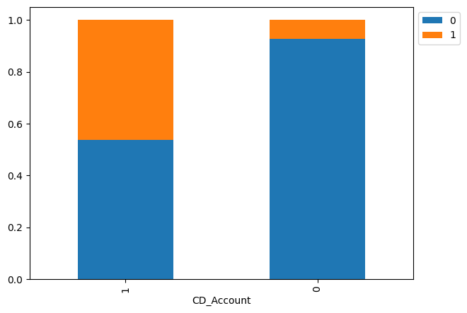

```python
# Personal_Loan Vs CD_Account
stacked_barplot(data, "CD_Account", "Personal_Loan")
```

**Observation**

- Customer with CD has higher acceptance of loan (46.4%)
- Non CD account holder acceptance rate is much lower (7.2%)
- Only 6% of the customers have a CD account.

```
Personal_Loan     0    1   All
Online
All            4520  480  5000
1              2693  291  2984
0              1827  189  2016
------------------------------------------------------------------------------------------------------------------------
```

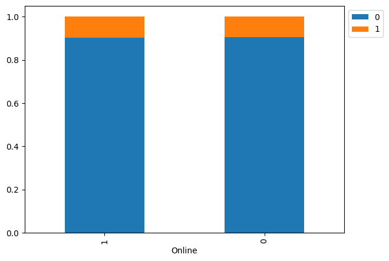

```python
# Personal_Loan Vs Online
stacked_barplot(data, "Online", "Personal_Loan")
```

**Observation**

- There is no significant difference between online user and non-user, it is about the same (9.8 vs 9.4%)

```
Personal_Loan     0    1   All
CreditCard
All            4520  480  5000
0              3193  337  3530
1              1327  143  1470
------------------------------------------------------------------------------------------------------------------------
```

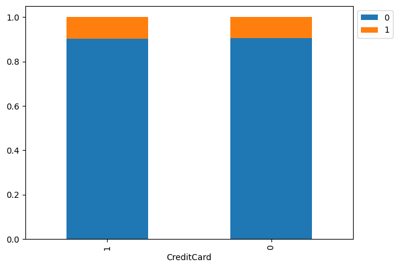

```python
# Personal_Loan Vs CreditCard
stacked_barplot(data, "CreditCard", "Personal_Loan")
```

**Observation**

- There is no significant difference between credit card holders user and non credit card holder, it is about the same (9.7 vs 9.5%)
- Majority of the customers don't have credit cards.

```
Personal_Loan          0    1   All
Securities_Account
All                 4520  480  5000
0                   4058  420  4478
1                    462   60   522
------------------------------------------------------------------------------------------------------------------------
```

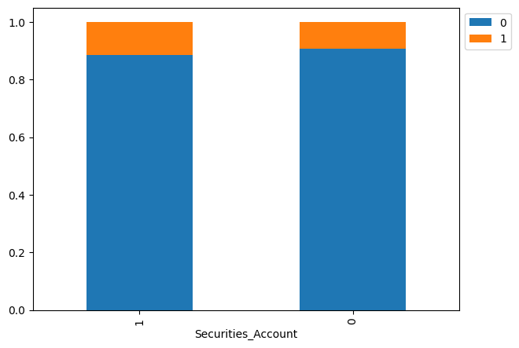

```python
# Personal_Loan Vs Securities_Account
stacked_barplot(data, "Securities_Account", "Personal_Loan")
```

**Observation**

- Customer with securities have more loan acceptance rate.

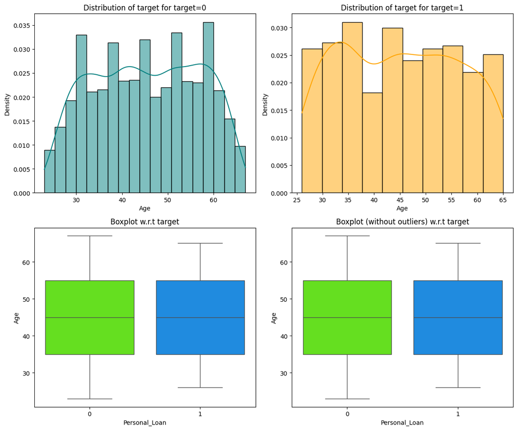

```python
# Lets analyse continuous variables
# Lets ignore Zip as it as no significant correlation with target
# Lets ignore experience as the information is represented by Age
cont_columns = ["Age",  "Income", "CCAvg", "Mortgage"]
# Lets do distribution_plot_wrt_target one by one

# Personal_Loan Vs Age
distribution_plot_wrt_target(data, "Age", "Personal_Loan")
```

**Observation**

- Age is a week predictor of loan acceptance
- Customers with age range 35-45 show slightly higher loan acceptance.

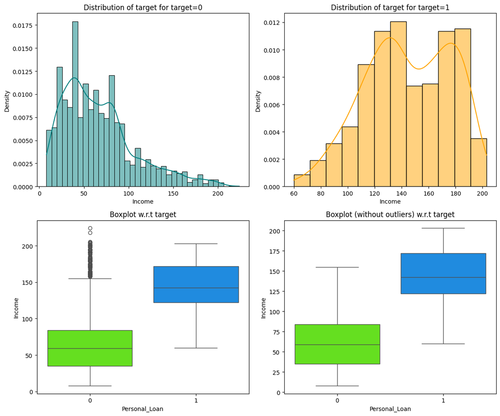

```python
# Personal_Loan Vs Income
distribution_plot_wrt_target(data, "Income", "Personal_Loan")
```

**Observation**

- The distribution is heavily right-skewed
- Income appears to be a stong preditor of loan acceptance.
- Customer with higher income are more likely accept loans.
- There are outlier but even after removing outliers shows clear separation of income rage, higher the income higher the loan acceptance.

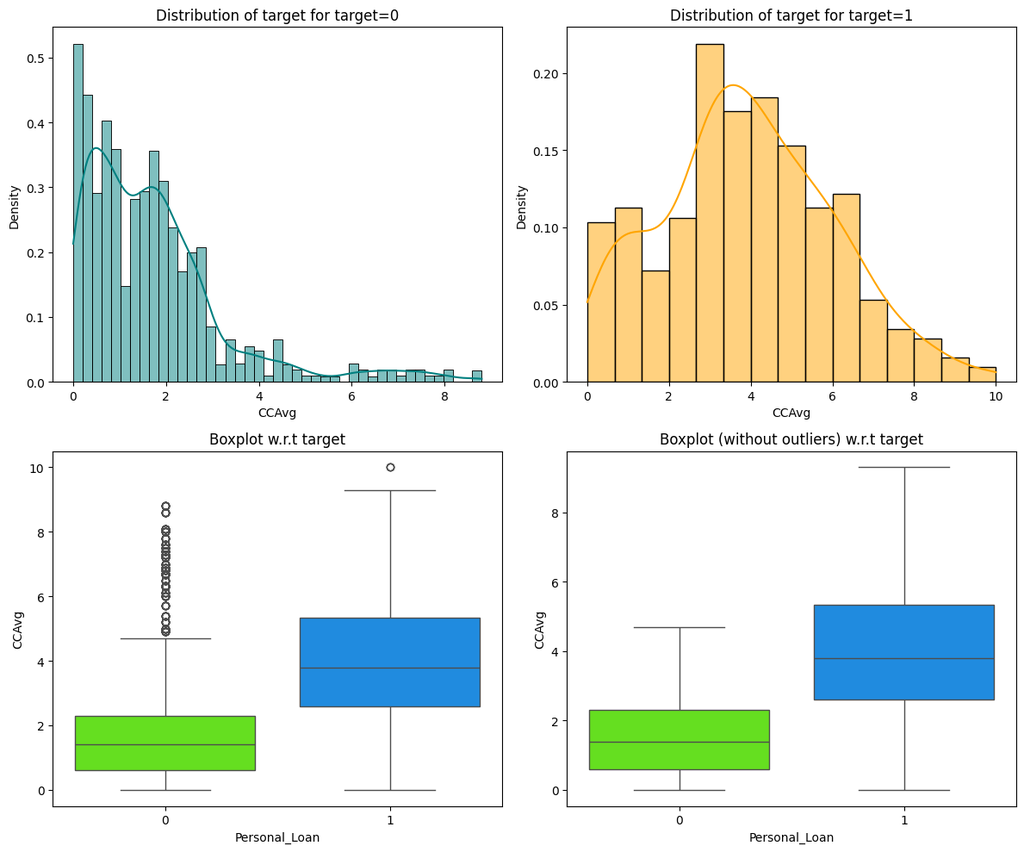

```python
# Personal_Loan Vs CCAvg
distribution_plot_wrt_target(data, "CCAvg", "Personal_Loan")
```

**Observation**

- The distribution is highly right-skewed.
- Like income Credit card spending is a strong predictor of loan acceptance.
- There is a significant differenace spending pattern and loan acceptance, even after removing outliers.
- Higher the credit card spenders are more likely to accept loans.

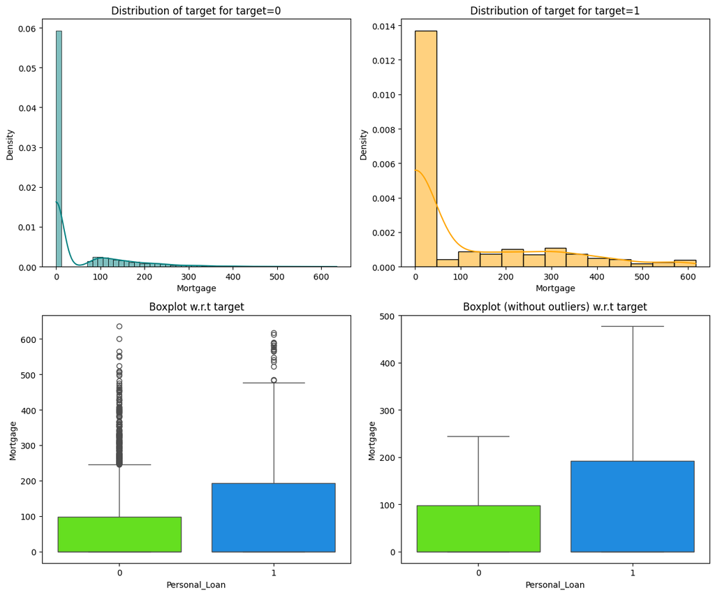

```python
# Personal_Loan Vs Mortgage
distribution_plot_wrt_target(data, "Mortgage", "Personal_Loan")
```

**Observation**

- The distribution is extreamely right-skewed.
- There are many outliers
- Mortgage amount appears to be meaning full predictor of loan acceptance.
- Customer with higher mortgage have higher acceptance rate.
- Many customer do not have mortgage.

## Data Preprocessing

- Missing value treatment
- Feature engineering (if needed)
- Outlier detection and treatment (if needed)
- Preparing data for modeling
- Any other preprocessing steps (if needed)

#### **Missing value treatment**

- There are no missing values

#### **Feature engineering**

- Identify categorical columns in the dataset and convert them to category
- Benefits
  - Memory efficienty
  - Better performance
  - More appropriate representation of categorical data.
- Categorical columns
  - Education (1: Undergrad, 2: Graduate, 3: Advanced/Professional)
  - Personal_Loan (0: No, 1: Yes)
  - Securities_Account (0: No, 1: Yes)
  - CD_Account (0: No, 1: Yes)
  - Online (0: No, 1: Yes)
  - CreditCard (0: No, 1: Yes).

```python
# Set categorical column list
cat_columns = ["Education", "Personal_Loan", "Securities_Account", "CD_Account", "Online", "CreditCard"]
# Convert categorical columns to category
data[cat_columns] = data[cat_columns].astype("category")
```

- Drop ZIPCode column from dataset as it as no significant correlation with target or any other variables.

```python
# Drop ZIPCode column
data.drop("ZIPCode", axis=1, inplace=True)
```

- We had already treated the experience data.

#### **Outlier treatment**

- The following variables have outliers
  - Income
  - CCAvg
  - Mortgage

We know this from the Univariate analysis done on these variables and Bivariate analysis of these variable with target.

From the EDA (distribution_plot_wrt_target), removal of outliers still shows clear separation between groups.

**So outlier treatment is not required.**

#### **Data Preparation for Modeling**

```python
# Dropping Experience as it is perfectly correlated with Age
X = data.drop(["Personal_Loan", "Experience"], axis=1)
Y = data["Personal_Loan"]

# Create dummy variables for Education since it's a categorical variable with 3 levels (1: Undergrad, 2: Graduate, 3: Professional/Advanced)
X = pd.get_dummies(X, columns=["Education"], drop_first=True)
X = X.astype(float)

# Splitting data in train and test sets (70-30 split)
X_train, X_test, y_train, y_test = train_test_split(
    X, Y, test_size=0.30, random_state=1
)
```

```python
# Print the shape of the training and test sets
print("Shape of Training set : ", X_train.shape)
print("Shape of test set : ", X_test.shape)
print("Percentage of classes in training set:")
print(y_train.value_counts(normalize=True))
print("Percentage of classes in test set:")
print(y_test.value_counts(normalize=True))
```

```
Shape of Training set :  (3500, 11)
Shape of test set :  (1500, 11)
Percentage of classes in training set:
Personal_Loan
0    0.905429
1    0.094571
Name: proportion, dtype: float64
Percentage of classes in test set:
Personal_Loan
0    0.900667
1    0.099333
Name: proportion, dtype: float64
```

- We seen around 90% of observation belongs to class 0 (Personal_loan not accepted) and 10% belonging to class 1 (loan accepted). This is about the same on both training and test sets.

## Model Building

### Model Evaluation Criterion

- Model can make wrong predictions as:
  - Predicting loan acceptance when customer won't accept (False positives) could waste marketing resource
  - Missing potential loan customer (Fales Negative) means lost business opportunities.
- Which affects the bussiness more?
  - Missing a potential loan customer (False Negative) is likely more costly than incorrectly identifying a non-customer (False Positive)
  - Lost loan opportunity means:
    - Lost interest revenue
    - Lost cross-selling opportunities
    - Potential customer might go to competitors.
- How to reduce the losses?

  This can be done by maximizing Recall.
  - Recall Metrix
    - Recall measures the ability to identify all potential loan customers
    - Recall = True Positives / (True Positives + False Negatives)
    - It shows how many actual loan acceptances we correctly identified
  - Business Impact:
    - Higher recall means fewer missed opportunities
    - Bank can then use human judgment to filter false positives
    - Better to have more potential leads than miss valuable customers

### Model Building

**Function to calculate different metrics to check performance of a classification model**

```python
# Defining a function to compute different metrics to check performance of a classification model built using sklearn

def model_performance_classification_sklearn(model, predictors, target):
    """
    Function to compute different metrics to check classification model performance

    model: classifier
    predictors: independent variables
    target: dependent variable
    """

    # predicting using the independent variables
    pred = model.predict(predictors)

    acc = accuracy_score(target, pred)  # to compute Accuracy
    recall = recall_score(target, pred)  # to compute Recall
    precision = precision_score(target, pred)  # to compute Precision
    f1 = f1_score(target, pred)  # to compute F1-score

    # creating a dataframe of metrics
    df_perf = pd.DataFrame(
        {"Accuracy": acc, "Recall": recall, "Precision": precision, "F1": f1,},
        index=[0],
    )

    return df_perf
```

```python
# Defining a function to plot confusion matrix

def confusion_matrix_sklearn(model, predictors, target):
    """
    To plot the confusion_matrix with percentages

    model: classifier
    predictors: independent variables
    target: dependent variable
    """
    y_pred = model.predict(predictors)
    cm = confusion_matrix(target, y_pred)
    labels = np.asarray(
        [
            ["{0:0.0f}".format(item) + "\n{0:.2%}".format(item / cm.flatten().sum())]
            for item in cm.flatten()
        ]
    ).reshape(2, 2)

    plt.figure(figsize=(6, 4))
    sns.heatmap(cm, annot=labels, fmt="")
    plt.ylabel("True label")
    plt.xlabel("Predicted label")
```

```python
# Print the decision tree
def tree_view(model,features):
  plt.figure(figsize=(20, 30))
  out = tree.plot_tree(
      model,
      feature_names=features,
      filled=True,
      fontsize=9,
      node_ids=False,
      class_names=None,
  )
  # below code will add arrows to the decision tree split if they are missing
  for o in out:
      arrow = o.arrow_patch
      if arrow is not None:
          arrow.set_edgecolor("black")
          arrow.set_linewidth(1)
  plt.show()
```

#### Decision Tree (default)

```python
# Define desition tree classifier for decision tree default

dt_default = DecisionTreeClassifier(random_state=1)
dt_default.fit(X_train, y_train)
```

```
DecisionTreeClassifier(random_state=1)
```

#### Checking Model Prerformance on training data

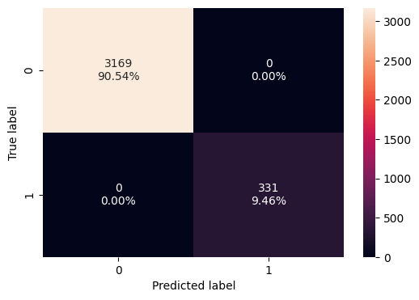

```python
# Confusion matrix on traning set
confusion_matrix_sklearn(dt_default, X_train, y_train)
```

```python
# Model performance on training set
dt_defaut_perf_train = model_performance_classification_sklearn(dt_default, X_train, y_train)
dt_defaut_perf_train
```

|  | Accuracy | Recall | Precision | F1 |
| --- | --- | --- | --- | --- |
| 0 | 1.0 | 1.0 | 1.0 | 1.0 |

**Observation**

- Perfect score on all the metrics, the error is 0, which is a clear indication of overfitting.
- Overfit model performs well on training set but fail to perform on unknow set or test set.
- We will have to check the performance on the test set.

#### Checking Model Performance on test data

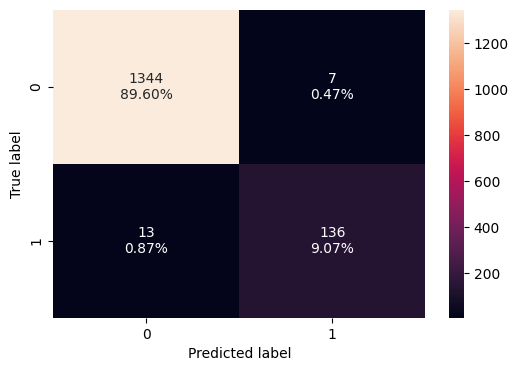

```python
# Confusion matrix on test set
confusion_matrix_sklearn(dt_default, X_test, y_test)
```

```python
# Model performance on test data
dt_defaut_perf_test = model_performance_classification_sklearn(dt_default, X_test, y_test)
dt_defaut_perf_test
```

|  | Accuracy | Recall | Precision | F1 |
| --- | --- | --- | --- | --- |
| 0 | 0.986667 | 0.912752 | 0.951049 | 0.931507 |

**Observation**

- The model seems to be more accurate (98.7)
- The recall percentage which we are interested is 91%. It is good but our goal is to maximize the recall.

#### Visualize Decision Tree

```python
# Get feature list
features = list(X_train.columns)
importances = dt_default.feature_importances_
indices = np.argsort(importances)
print("Features:",features)
print("Importance:",importances)
```

```
Features: ['Age', 'Income', 'Family', 'CCAvg', 'Mortgage', 'Securities_Account', 'CD_Account', 'Online', 'CreditCard', 'Education_2', 'Education_3']
Importance: [0.03240355 0.31519791 0.25981147 0.05518383 0.00599573 0.
 0.01727344 0.00222447 0.00111223 0.16619226 0.1446051 ]
```

```
Decision tree depth: 10
```

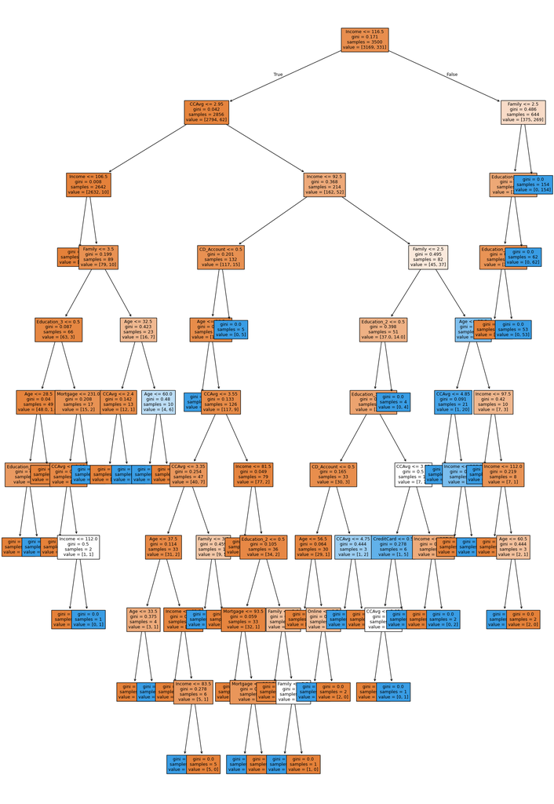

```python
# Display tree for decision tree default
depth = dt_default.get_depth()
print(f"Decision tree depth: {depth}")
## Print the decision tree
tree_view(dt_default,features)
```

```python
# Text report showing the rules of a decision tree -
print(tree.export_text(dt_default, feature_names=features, show_weights=True))
```

```
|--- Income <= 116.50
|   |--- CCAvg <= 2.95
|   |   |--- Income <= 106.50
|   |   |   |--- weights: [2553.00, 0.00] class: 0
|   |   |--- Income >  106.50
|   |   |   |--- Family <= 3.50
|   |   |   |   |--- Education_3 <= 0.50
|   |   |   |   |   |--- Age <= 28.50
|   |   |   |   |   |   |--- Education_2 <= 0.50
|   |   |   |   |   |   |   |--- weights: [5.00, 0.00] class: 0
|   |   |   |   |   |   |--- Education_2 >  0.50
|   |   |   |   |   |   |   |--- weights: [0.00, 1.00] class: 1
|   |   |   |   |   |--- Age >  28.50
|   |   |   |   |   |   |--- weights: [43.00, 0.00] class: 0
|   |   |   |   |--- Education_3 >  0.50
|   |   |   |   |   |--- Mortgage <= 231.00
|   |   |   |   |   |   |--- CCAvg <= 1.95
|   |   |   |   |   |   |   |--- weights: [14.00, 0.00] class: 0
|   |   |   |   |   |   |--- CCAvg >  1.95
|   |   |   |   |   |   |   |--- Income <= 112.00
|   |   |   |   |   |   |   |   |--- weights: [1.00, 0.00] class: 0
|   |   |   |   |   |   |   |--- Income >  112.00
|   |   |   |   |   |   |   |   |--- weights: [0.00, 1.00] class: 1
|   |   |   |   |   |--- Mortgage >  231.00
|   |   |   |   |   |   |--- weights: [0.00, 1.00] class: 1
|   |   |   |--- Family >  3.50
|   |   |   |   |--- Age <= 32.50
|   |   |   |   |   |--- CCAvg <= 2.40
|   |   |   |   |   |   |--- weights: [12.00, 0.00] class: 0
|   |   |   |   |   |--- CCAvg >  2.40
|   |   |   |   |   |   |--- weights: [0.00, 1.00] class: 1
|   |   |   |   |--- Age >  32.50
|   |   |   |   |   |--- Age <= 60.00
|   |   |   |   |   |   |--- weights: [0.00, 6.00] class: 1
|   |   |   |   |   |--- Age >  60.00
|   |   |   |   |   |   |--- weights: [4.00, 0.00] class: 0
|   |--- CCAvg >  2.95
|   |   |--- Income <= 92.50
|   |   |   |--- CD_Account <= 0.50
|   |   |   |   |--- Age <= 26.50
```

[output cut: 93 more lines]

```
|   |   |   |   |   |   |   |--- Age <= 60.50
|   |   |   |   |   |   |   |   |--- weights: [0.00, 1.00] class: 1
|   |   |   |   |   |   |   |--- Age >  60.50
|   |   |   |   |   |   |   |   |--- weights: [2.00, 0.00] class: 0
|--- Income >  116.50
|   |--- Family <= 2.50
|   |   |--- Education_3 <= 0.50
|   |   |   |--- Education_2 <= 0.50
|   |   |   |   |--- weights: [375.00, 0.00] class: 0
|   |   |   |--- Education_2 >  0.50
|   |   |   |   |--- weights: [0.00, 53.00] class: 1
|   |   |--- Education_3 >  0.50
|   |   |   |--- weights: [0.00, 62.00] class: 1
|   |--- Family >  2.50
|   |   |--- weights: [0.00, 154.00] class: 1
```

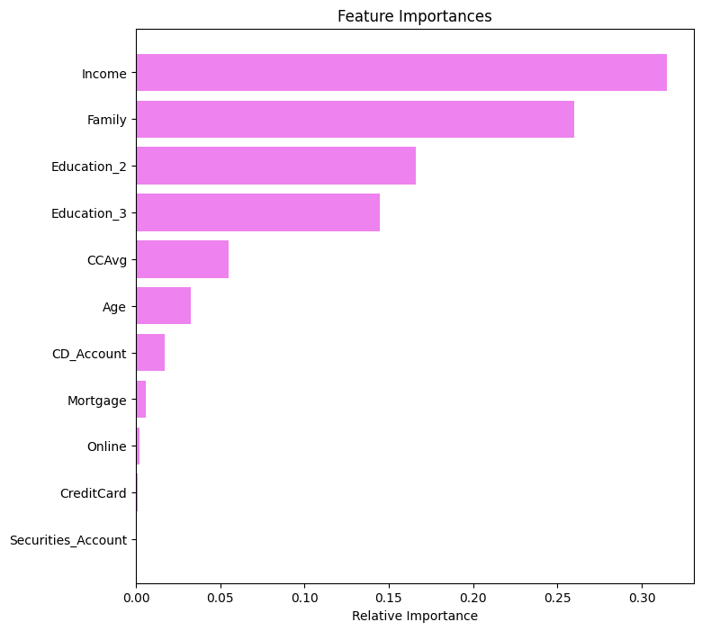

```python
# importance of features in the tree building

importances = dt_default.feature_importances_
indices = np.argsort(importances)

plt.figure(figsize=(8, 8))
plt.title("Feature Importances")
plt.barh(range(len(indices)), importances[indices], color="violet", align="center")
plt.yticks(range(len(indices)), [features[i] for i in indices])
plt.xlabel("Relative Importance")
plt.show()
```

**Model Performance observation**

- The defaut Decision Tree model is overfitted.
- The recall metrics is less than accuracy on test data.
- The top 4 important features are Income, Family, Education and Credit card spendings.

## Model Performance Improvement

#### Decision Tree (Pre-pruning)

- Hyperparameter tuning is crucial because it directly affects the performance of a model.
- Unlike model parameters which are learned during training, hyperparameters need to be set before training.
- Effective hyperparameter tuning helps in improving the performance and robustness of the model.
- The below custom loop for hyperparameter tuning iterates over predefined parameter values to identify the best model based on the metric of choice (recall score).

```python
# Define the parameters of the tree to iterate over
max_depth_values = np.arange(2, 11, 2)
max_leaf_nodes_values = [10, 50, 75, 150, 250]
min_samples_split_values = [10, 30, 50, 70]

# Initialize variables to store the best model and its performance
best_estimator = None
best_score_diff = float('inf')
best_test_score = 0.0

# Iterate over all combinations of the specified parameter values
for max_depth in max_depth_values:
    for max_leaf_nodes in max_leaf_nodes_values:
        for min_samples_split in min_samples_split_values:

            # Initialize the tree with the current set of parameters
            estimator = DecisionTreeClassifier(
                max_depth=max_depth,
                max_leaf_nodes=max_leaf_nodes,
                min_samples_split=min_samples_split,
                class_weight='balanced',
                random_state=42
            )

            # Fit the model to the training data
            estimator.fit(X_train, y_train)

            # Make predictions on the training and test sets
            y_train_pred = estimator.predict(X_train)
            y_test_pred = estimator.predict(X_test)

            # Calculate recall scores for training and test sets
            train_recall_score = recall_score(y_train, y_train_pred)
            test_recall_score = recall_score(y_test, y_test_pred)

            # Calculate the absolute difference between training and test recall scores
            score_diff = abs(train_recall_score - test_recall_score)

            # Update the best estimator and best score if the current one has a smaller score difference
            if (score_diff < best_score_diff) & (test_recall_score > best_test_score):
                best_score_diff = score_diff
                best_test_score = test_recall_score
                best_estimator = estimator

# Print the best parameters
print("Best parameters found:")
print(f"Max depth: {best_estimator.max_depth}")
print(f"Max leaf nodes: {best_estimator.max_leaf_nodes}")
print(f"Min samples split: {best_estimator.min_samples_split}")
print(f"Best test recall score: {best_test_score}")
```

```
Best parameters found:
Max depth: 2
Max leaf nodes: 10
Min samples split: 10
Best test recall score: 1.0
```

```python
# Create an instance of of best model
dt_pre_pruned = best_estimator
# fitting the best model to the training data
dt_pre_pruned.fit(X_train, y_train)
```

```
DecisionTreeClassifier(class_weight='balanced', max_depth=2, max_leaf_nodes=10,
                       min_samples_split=10, random_state=42)
```

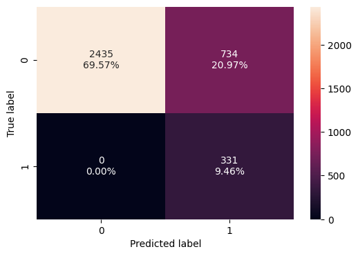

```python
# Confusion matrix on traning set
confusion_matrix_sklearn(dt_pre_pruned, X_train, y_train)
```

```python
#Model performance on training set
dt_pre_pruned_perf_train = model_performance_classification_sklearn(dt_pre_pruned, X_train, y_train)
dt_pre_pruned_perf_train
```

|  | Accuracy | Recall | Precision | F1 |
| --- | --- | --- | --- | --- |
| 0 | 0.790286 | 1.0 | 0.310798 | 0.474212 |

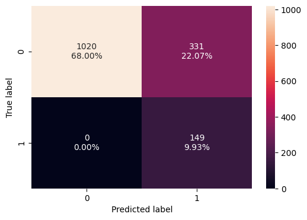

```python
# Confusion matrix on test set
confusion_matrix_sklearn(dt_pre_pruned, X_test, y_test)
```

```python
#Model performance on training set
dt_pre_pruned_perf_test = model_performance_classification_sklearn(dt_pre_pruned, X_test, y_test)
dt_pre_pruned_perf_test
```

|  | Accuracy | Recall | Precision | F1 |
| --- | --- | --- | --- | --- |
| 0 | 0.779333 | 1.0 | 0.310417 | 0.473768 |

##### **Visualize Decision Tree (Pre-Pruned)**

```
Decision tree depth: 2
```

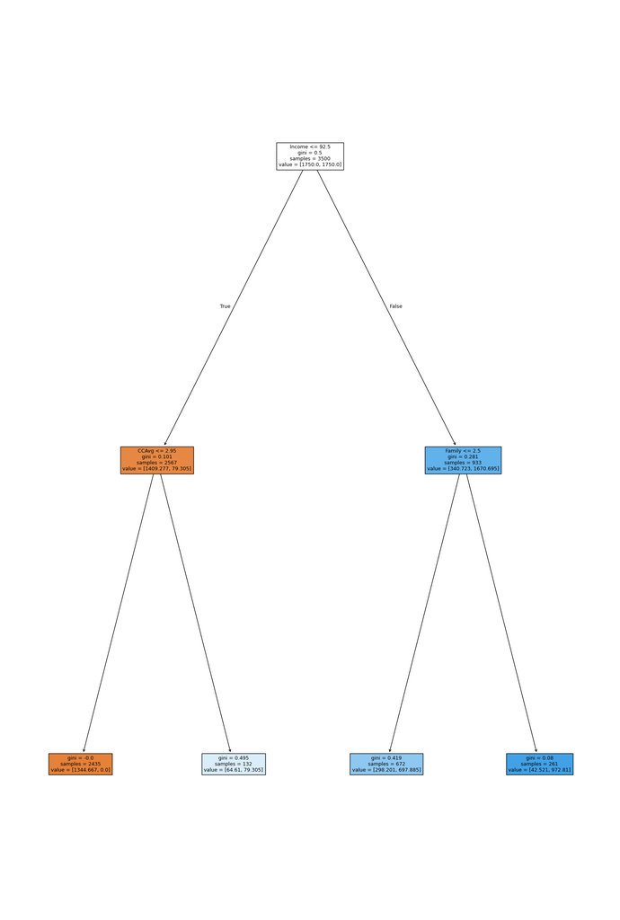

```python
# Display tree for decision tree Pre-Pruned
depth = dt_pre_pruned.get_depth()
print(f"Decision tree depth: {depth}")
## Print the decision tree
tree_view(dt_pre_pruned,features)
```

```python
# Text report showing the rules of a decision tree -
print(tree.export_text(dt_pre_pruned, feature_names=features, show_weights=True))
```

```
|--- Income <= 92.50
|   |--- CCAvg <= 2.95
|   |   |--- weights: [1344.67, 0.00] class: 0
|   |--- CCAvg >  2.95
|   |   |--- weights: [64.61, 79.31] class: 1
|--- Income >  92.50
|   |--- Family <= 2.50
|   |   |--- weights: [298.20, 697.89] class: 1
|   |--- Family >  2.50
|   |   |--- weights: [42.52, 972.81] class: 1
```

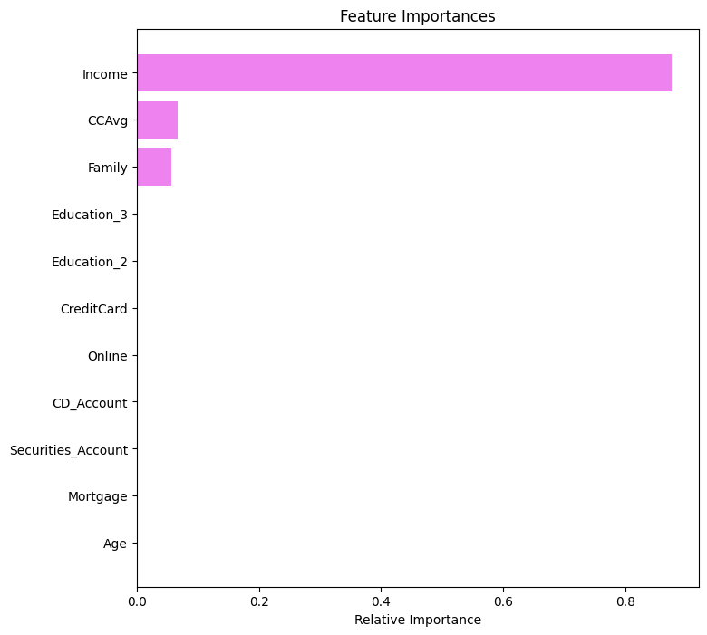

```python
# importance of features in the tree building

importances = dt_pre_pruned.feature_importances_
indices = np.argsort(importances)

plt.figure(figsize=(8, 8))
plt.title("Feature Importances")
plt.barh(range(len(indices)), importances[indices], color="violet", align="center")
plt.yticks(range(len(indices)), [features[i] for i in indices])
plt.xlabel("Relative Importance")
plt.show()
```

##### **Model Performance observation**

- The best model depth is only 2.
- The recall metrics is 100%, the other metrics (accuracy, precission and F1 score) are not optimal.
- The metrics on both training and test set are similar.
- The top 3 important features are Income, Credit card spendings and Family.